# M1 CV - TP3 : Un arc-en-ciel de couleurs :D

# Ex 4. : Wololo !

Bon là, c'est pas du tout un nouvel espace de couleur, c'est juste un titre d'exo... Chargez l'image iron_man.jpg et affichez-la (EN RGB !).

[figure not shown]

```python
# A compléter
# Chargement et affichage de l'image iron_man.jpg
print_image(img4)
```

```python
img4.shape
```

```
(676, 1200, 3)
```

J'ai un caprice : je n'aime pas le rouge. C'est la seule chose que je déteste dans ce monde : la couleur rouge. J'aimerai que Iron Man ne soit plus rouge mais bleu. Par contre, j'aime le jaune, donc je veux qu'on garde la couleur jaune. Et le bleu, je veux qu'il reste bleu aussi... On garde tout, sauf le rouge, qu'on va mettre en bleu.

Pour résumé : l'objectif de cet exercice va être de sélectionner les pixels rouges de l'image Iron Man et les mettre en bleus, tout en faisant que l'image reste naturelle. Je vous laisse la liberté de faire comme vous le souhaitez, mais je vous recommande fortement de revoir l'exercice 3 si le message passé n'est pas clair...

Pour réaliser cet exercice, on peut le diviser en 2 parties : la sélection des pixels rouges, et ensuite le changement de teinte de ces pixels.

```python
i_m = cv2.resize(img4, (600,600))
```

```
[[208 230 244]
 [208 230 244]
 [206 228 242]
 ...
 [186 212 227]
 [190 216 231]
 [190 216 231]]
```

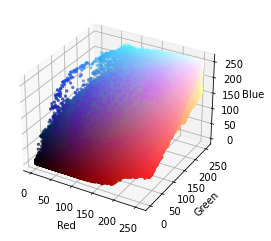

```python
# A compléter
# Exo 4, à vous de jouer ;)
pixel_colors_im = print_img_in_rgb_space(i_m)
```

```python
# A compléter
# Définissez votre image hsv calculée (manuellement ou par OpenCV)

def print_img_in_hsv_space2(img,pixel_colors):
    hsv = cv2.cvtColor(img, cv2.COLOR_RGB2HSV)
    #hsv_image = hsv
    #hsv_image = img_normalisation(hsv)

    # resize image
    hsv = cv2.resize(hsv, (600,600))

    h, s, v = cv2.split(hsv)
    s=s/255.
    v=v/255.
    fig = plt.figure()
    axis = fig.add_subplot(1, 1, 1, projection="3d")

    x = v*s*np.cos(np.deg2rad(h.astype(np.uint16)*2))
    y = v*s*np.sin(np.deg2rad(h.astype(np.uint16)*2))

    print("h_size : ",h.shape)
    print("s_size : ",s.shape)
    print("v_size : ",v.shape)
    print("x_size : ",x.shape)
    print("y_size : ",y.shape)

    print(pixel_colors)

    axis.scatter(x.flatten(), y.flatten(), v.flatten(), facecolors=pixel_colors, marker=".")

    plt.show()
    return hsv#hsv
```

```
h_size :  (600, 600)
s_size :  (600, 600)
v_size :  (600, 600)
x_size :  (600, 600)
y_size :  (600, 600)
```

[output not shown]

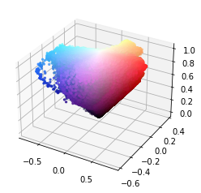

```python
iron_man_rouge = print_img_in_hsv_space2(i_m,pixel_colors_im)
```

[output not shown]

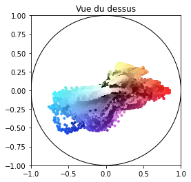

```python
x, y = print_chroma_from_the_top(iron_man_rouge,pixel_colors_im)
```

```
lines_size :  2
c_size :  (2, 4)
lc_ :  <matplotlib.collections.LineCollection object at 0x7fa2e350b940>
```

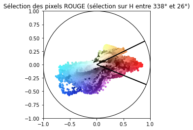

```python
lines, c, lc, cercle, a, b = print_and_get_color_interval(x, y, 338, 26,pixel_colors_im,"ROUGE")
```

```python
img_iron_man_hsv = np.copy(iron_man_rouge)
```

```python
def changeHUE(img_hsvchange, a, b):

    print(a)
    print(b)

    a = a/2
    b = b/2

    size = img_hsvchange.shape
    print(size)

    for i in range(size[0]):
        for j in range(size[1]):
            current_pix = img_hsvchange[i,j,0]
            if current_pix >= 0 and current_pix <= a:
                img_hsvchange[i,j,0]=107
            elif current_pix >= b and current_pix <= 180:
                img_hsvchange[i,j,0]=107

    img_hsvchange = cv2.resize(img_hsvchange, (1200,676))

    return img_hsvchange
```

```python
img_last = changeHUE(img_iron_man_hsv, b, a)
```

```
26
338
(600, 600, 3)
```

[figure not shown]

```python
print_image(img_last)
```

[figure not shown]

```python
print_image(cv2.cvtColor(img_last, cv2.COLOR_HSV2RGB))
```

## Rendu de TP

Le rendu qui vous est demandé pour les TP de TIM est la version HTML de ce notebook. Pour l'obtenir: Fichier, télécharger au format, HTML (.html).